# Report

Team 4

11/12/2020

## Background and questions raised

For this project, we wanted to look at basketball data that includes team stats for all Division 1 Men’s basketball teams for the years 2015-2020. Since this dataset includes all Division One teams, we will look at which stats correspond with higher achieving teams. We can do this for all teams and then specifically focus in on Iowa State to see how they perform over the years. It will be very interesting to see over the time period how each team performs and to determine why or why they aren’t making it to the end of season tournament. Specifically, we wanted to determine how the following statistics impact the number of wins or wins above the bubble of teams in the Big 12 Conference:

- 3-Point Shooting
- 2-Point Shooting
- Rebounds
- Steals to Turn Over Ratio
- Free-throws

## Obtaining/Cleaning the data

Data set cbb contains statistics for each team in seasons 2015-2019 combined. Data set cbb[n] has statistics for each team for season n. The the data for 2020, cbb20, was joined to cbb since it was not included automatically.

## Analysis 1

Author - Joel Martin

For this analysis I looked at the 3-point shooting percentage statistic in our data set. 3-Point Shooting Percentage is the number of 3-Point shots scored, divided by the number of 3-Point shoots taken.

The first area I wanted to explore was to see how each teams 3-point shooting percentage changed over the course of 6 years from 2015 - 2020.

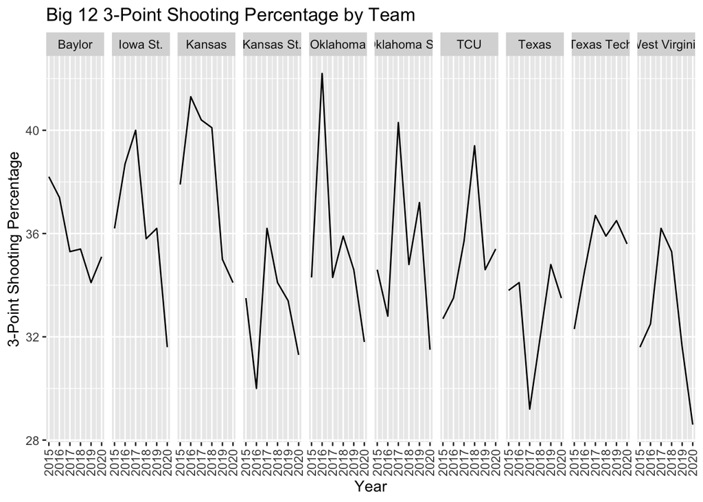

Based on the above graph we can see that most teams ended 2020 with a worse percentage than when the data started in 2015. The two teams that did not follow this trend are TCU and Texas Tech who both had a better shooting percentage at the end of 2020 compared to their starting percentage in 2015.

To get a better idea of how Iowa State compares to its competition in the Big 12 conference, I made a bar graph which shows each team’s average 3-point shooting percentage over the 6 years.

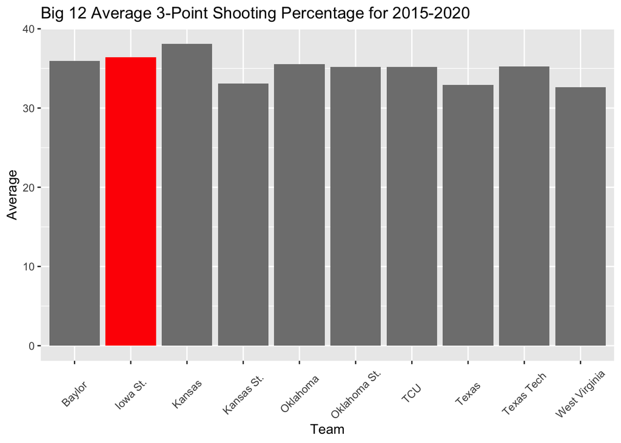

With this graph we can see that Kansas holds the first-place spot and Iowa State just barely beats Baylor for second place in the Big 12 conference.

Another question I answered was does a higher 3-Point percentage lead to more wins? To visualize this, I found the percentage of wins for each team from 2015 - 2020 then I compared it to each team’s average 3-point shooting percentage for each of those 6 years.

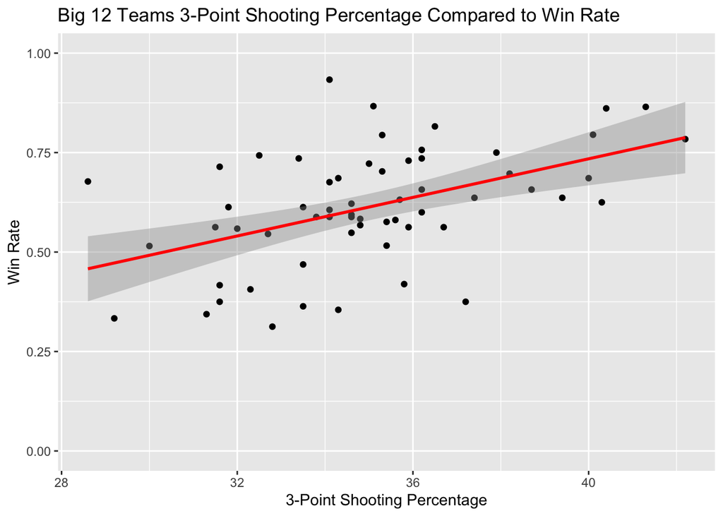

With the use of a linear regression line in this scatterplot we can see that a higher 3-point percentage does lead to a higher win rate. While a higher 3-point shooting percentage doesn’t necessarily mean that a team will win, for example if a team shot one 3-point shot and makes it and doesn’t score or try to score another 3-point shot for that season, they would have a 100% shooting rate but that most likely would mean they didn’t do well in the season. However overall, teams wanting to consistently win more games should strive for a higher 3-point shooting percentage.

## Analysis 2

Author - Rabsa Naseer

The Wins Above Bubble (WAB) is the amount of wins a team has minus the amount of wins an average bubble team would expect vs. the team’s schedule [(source)](https://sethburn.wordpress.com/2019/03/04/parcells-defined-why-unc-greensboro-belongs-in-the-ncaa-tournament/). Thus, a higher WAB would indicate that a team is doing well. The WAB also determines whether the team makes it to the NCAA March Madness Tournament or not.

In this primary analysis, I compare Iowa State’s WAB values for each year to those of the other teams that are part of the Big 12 Conference.

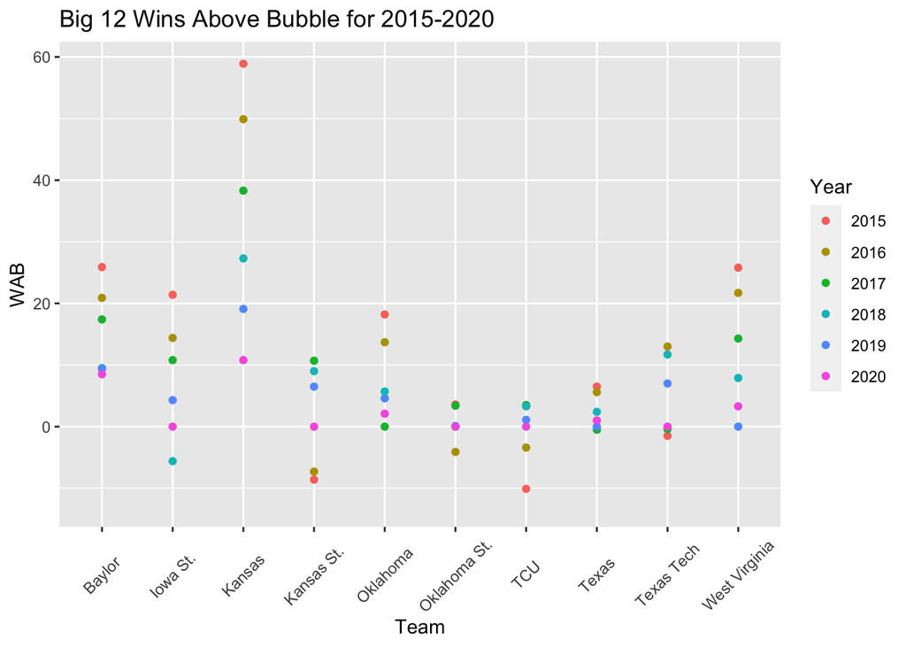

According to the above plot, Iowa State was doing well in terms of getting positive WAB values in 2015, 2016, and 2017. But more recently, they have not been doing well in their number of wins, as the resulting WAB scores are lower; 2018 hitting below 0 and 2020 at 0. Most of the other teams, especially Kansas, seem to be doing much better in their recent years compared to Iowa State.

I then wanted to see what affects the WAB, so I created four plots, utilizing ggarange from the ggpubr library, comparing the three point shooting percentage, two point shooting percentage, turnover rate, and free throw rate to the WAB for the teams.

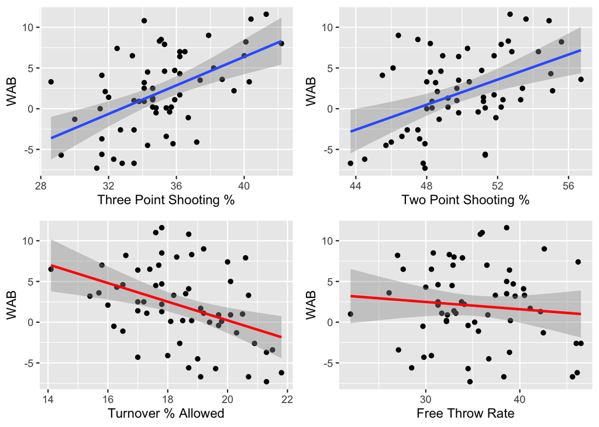

From this analyses, we can see that higher three point and two point shooting percentages yield higher WAB, according to the positive regression lines. Inversely, we see that higher Allowed Turnover % and Free Throw Rate are yielding lower WAB, Allowed Turnover % giving us a more negative relationship. For teams to get better WAB values, especially Iowa State, they should work on lowering the number of turnovers, number of times the ball is stolen from the team, and possibly how well they free throw.

## Analysis 3

Author - Joseph Strobel

For this analysis I will look at how rebounding affects team success in the Big 12.

To begin, we simply compare how teams are rebounding over the years 2015-2020

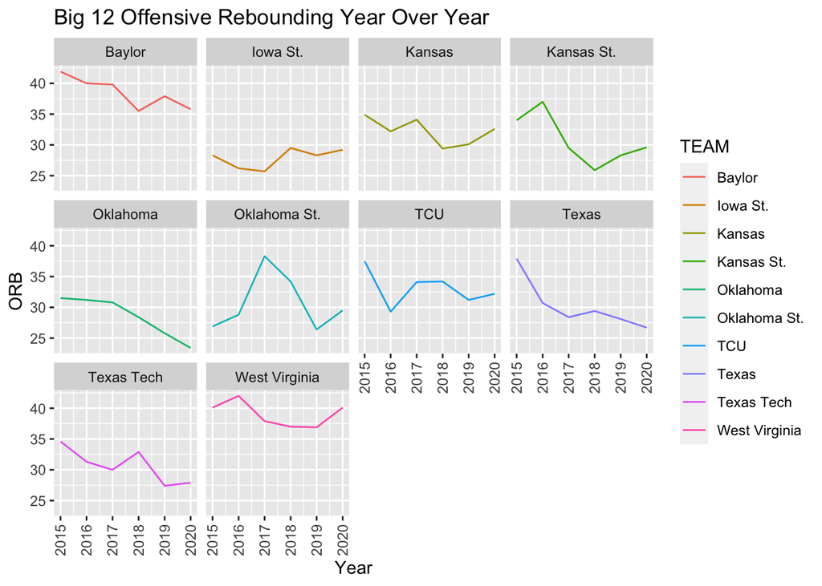

We can see that Baylor and West Virginia are consistently atop the Big 12 conference in respect to offensive rebounding while Iowa State as well as other tend to be near the bottom of the conference.

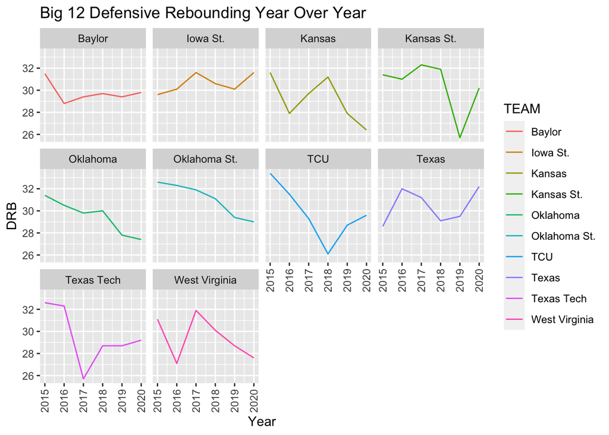

Next, we will analyze whether offensive and defensive rebounding have an impact on winning games.

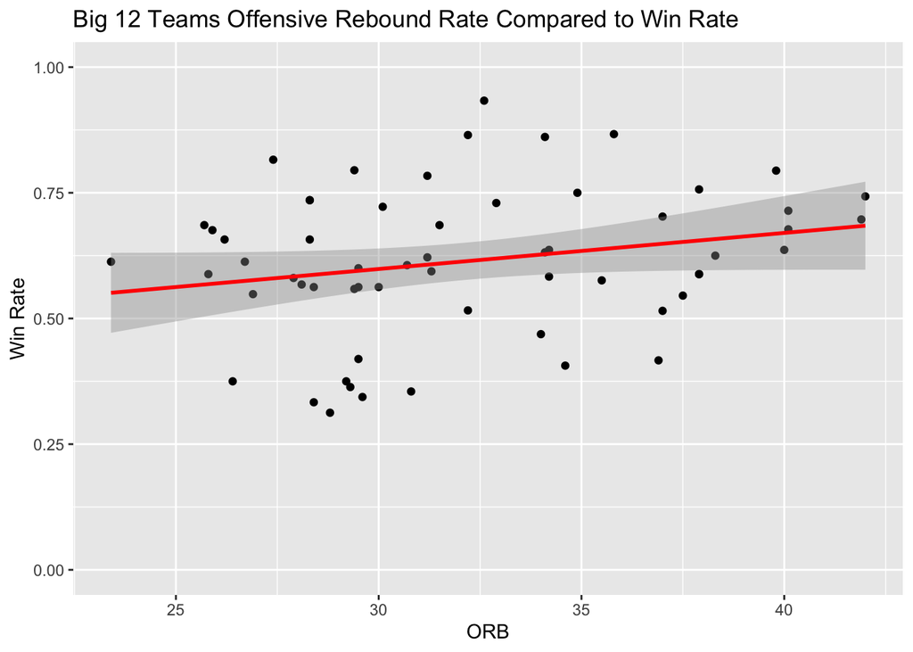

From the plot, we can see that there is a slight positive correlation between ORB and Win Rate. One reason for a positive coorelation could be because team that get more offensive rebounds will have more opportunities for second chance points and will score more often which leads to winning.

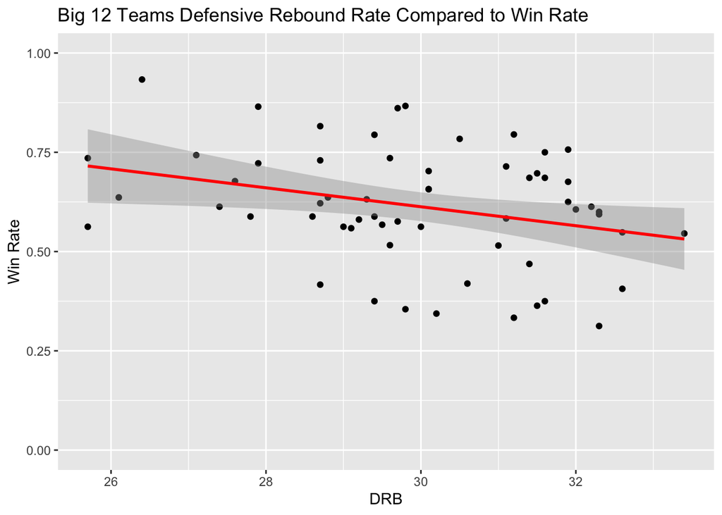

In this plot we can see that there is a negative correlation between defensive rebounding rate and win rate. This is an odd correlation because defensive rebounding is generally thought of as important to prevent second chance points from the opposing team as well as giving your team another offensive possession.

## Analysis 4

Author - Ahmed Hassan

When a player on defense takes hold of the basketball from an offensive player, a steal happens. A turnover is caused when a player with a basketball possession loses control as a result of their own mistake (throwing the basketball out-of-bounds or the mistake of an opponent. In order to determine a player’s ball control and ball handling capabilities, a Steal-to-Turnover Ratio is used.

For the first graph, I’m going to explore which team has the highest Steal to Turn Over ratio within the Big 12.

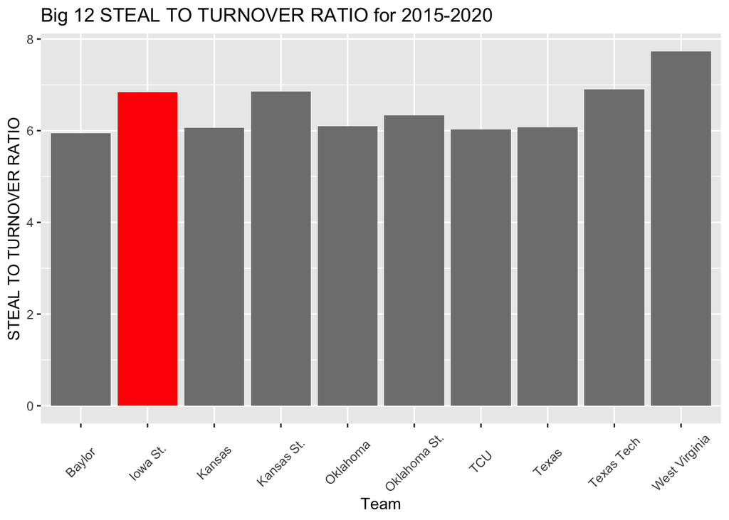

As we can see from the above analysis, Iowa State is surprisingly among the 3 schools qualifying for the second place spot in terms of Steal to turn over ratio, along with Kansas St and Texas Tech. West Virginia being in the first spot. Safe to say Iowa state has some impressive players with ball control and ball handling capabilities.

## Analysis 5

Author - Wil Hillmer

For this Analysis I am looking at Free Throw Ratio(FTR) and wins in the Big 12. FTR is the ratio of Free Throw Attempts to Field Goal Attempts and is calculated by dividing Free Throw Attempts by Field Goal Attempts and converted to a percentage. I am looking into whether or not a low Free Throw Ratio leads to a higher win rate.

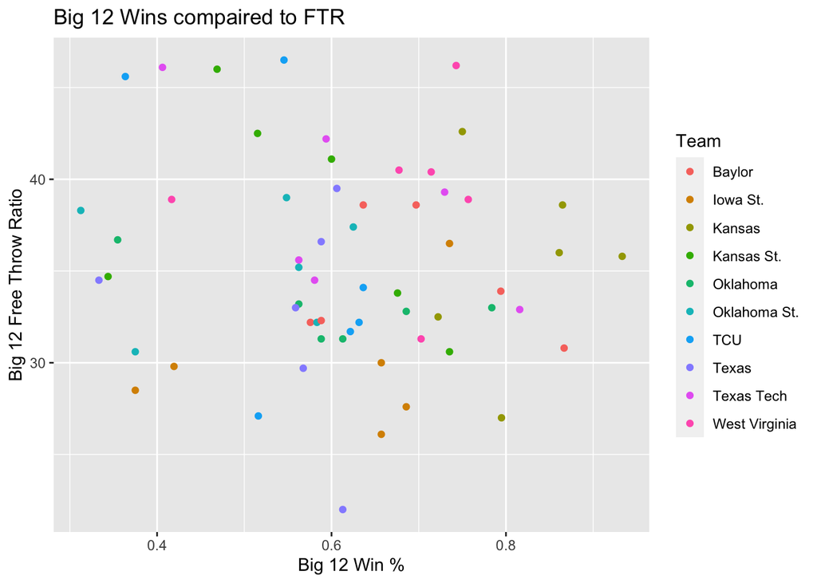

The data of the graph shows that there is little to no correlation between how a team performs and what their Free Throw Ratio is. Next I am going to craft a bar chart to compare Iowa State’s FTR to other colleges in the Big 12

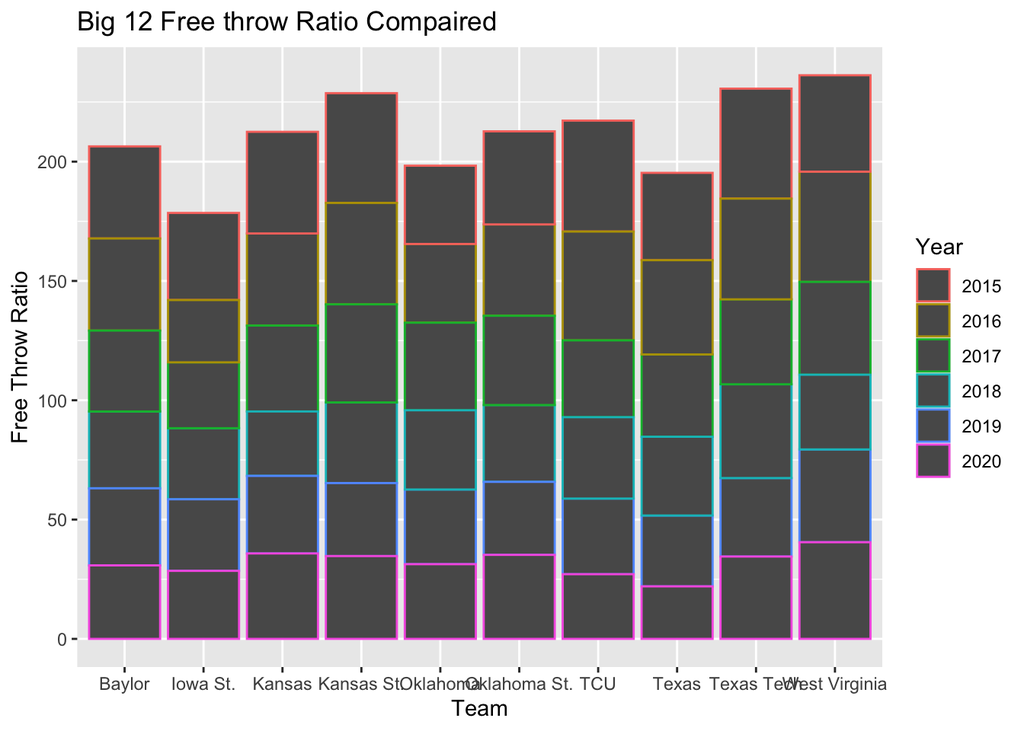

From the graph we can determine that the years Iowa State has had a relatively low FTR meaning that Iowa State players most likely take more jump shots outside of traffic than other colleges.

## Conclusion

Overall, there are many different variables that effect whether a team wins or loses a game in basketball. Some of these factors include 3- and 2-point shooting, turnover, and rebound percentages. Better percentages in these factors leads to higher wins above bubble (WAB) and wins in general which in turn can lead to better seasons, even for Iowa State. However, one statistic shows the opposite. A higher DRB rate does not lead to a higher win rate.

## Contributions

Each analysis lists its respective author, who created the analysis and included it in the report. Data was uploaded and cleaned by Joel Martin. Background and conclusion were written by Joseph Strobel. Report was formatted by Rabsa Naseer and Joseph Strobel.